# Схема аутентификации пользователей с помощью логинов и паролей.

Операционные системы

Мустафина А. Ю.

Российский университет дружбы народов, Москва, Россия

7 апреля 2025

# Информация

## Докладчик

- Мустафина Аделя Юрисовна
- НКАбд-03-24
- Компьютерные и информационнные науки
- Российский университет дружбы народов
- https://github.com/aymustafina/study_2024-2025_os-intro

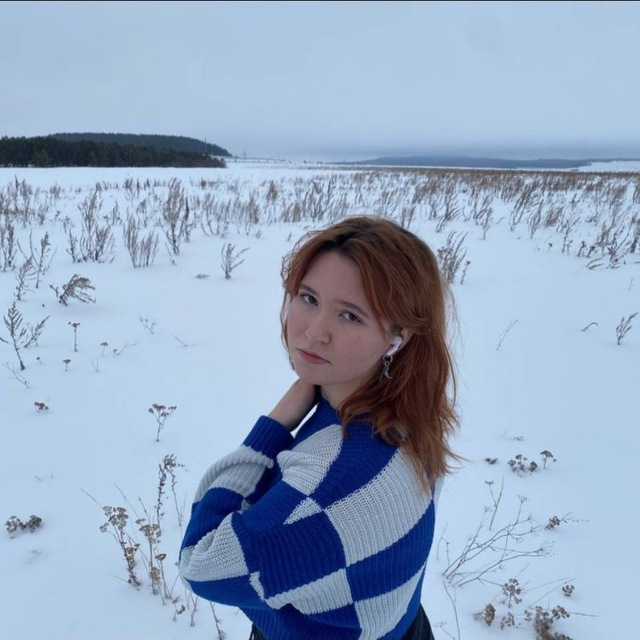

## Преподаватель

- Кулябов Дмитрий Сергеевич
- д.ф.-м.н., профессор
- профессор кафедры прикладной информатики и теории вероятностей
- Российский университет дружбы народов
- kulyabov-ds@rudn.ru
- https://yamadharma.github.io/ru/

## Цели и задачи

- Узнать, что такое аутентификация
- Изучить процесс аутентификации
- Как хранятся данные о пользователях
- Проверка пароля
- Заключение

## Аутентификация

Аутентификация пользователей — важнейший аспект управления пользователями в Linux, обеспечивающий доступ к системе только авторизованным пользователям. Как правило, при этом пользователю необходимо ввести пароль или предоставить секретный ключ.

В Linux аутентификация реализована с использованием логинов и паролей, что является стандартным подходом в UNIX-подобных системах.

## Аутентификация на основе пароля

Аутентификация на основе пароля — наиболее распространённый метод аутентификации пользователей в Linux. При входе в систему пользователи вводят своё имя пользователя и соответствующий пароль для подтверждения своей личности.

## Аутентификация на основе ключей Secure Shell (SSH)

Аутентификация на основе ключей Secure Shell (SSH) обеспечивает более безопасную альтернативу аутентификации на основе паролей. Пользователи генерируют пару открытого и закрытого ключей, где открытый ключ хранится на сервере, а закрытый ключ надёжно хранится на устройстве пользователя.

Преимущества SSH-аутентификации:

- Более высокая безопасность, так как ключи сложнее подделать, чем пароли.
- Удобство — пользователю не нужно каждый раз вводить пароль.

## Процесс аутентификации

В UNIX сеанс работы пользователя начинается с его аутентификации и заканчивается его выходом из системы.

1. Запрос регистрационных данных Процесс getty ожидает активности пользователя на терминальной линии. При обнаружении активности он выводит приглашение ввести логин и пароль.

## Процесс аутентификации

2. Проверка подлинности данных После ввода логина запускается программа login, которая проверяет подлинность введённых данных. Основным механизмом проверки является сравнение введённого пароля с хэшем, хранящимся в системе.

## Процесс аутентификации

3. Запуск командной оболочки Если пароль введён верно, login запускает командную оболочку (например, /bin/bash) с установленными идентификаторами пользователя (UID) и группы (GID). Эти идентификаторы определяют права доступа для всех процессов, запущенных пользователем в текущем сеансе. Она проверяет правильность ввода имени и пароля пользователя, меняет каталог на домашний, выстраивает окружение и запускает командный интерпретатор. Команду login нельзя запускать из командной строки - это вызовет ошибку и может привести к завершению сеанса.

## Схема процесса аутентификации

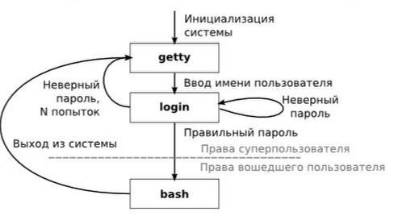

Схема

## Хранение данных о пользователях

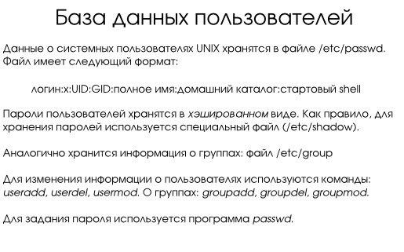

База данных пользователя

## Хранение данных о пользователях

Пример строки из файла /etc/passwd:

root:x:0:0:root:/root:/bin/bash

Пример строки из файла /etc/shadow:

root:$6$randomsalt$hashedpassword:19180:0:99999:7:::

## Управление пользователями и паролями

Для управления пользователями и их паролями в Linux используются следующие команды:

- useradd — добавление нового пользователя.
- userdel — удаление пользователя.
- passwd — изменение пароля пользователя.
- usermod — изменение параметров пользователя.

## Заключение

Схема аутентификации пользователей в Linux с использованием логинов и паролей является надёжным и проверенным временем механизмом. Использование современных алгоритмов хеширования, а также правильное управление паролями значительно повышают уровень защиты системы.

Несмотря на свою простоту, эта схема эффективно защищает систему от несанкционированного доступа, что делает её важным элементом информационной безопасности в Linux.